# 1_analisis_exploratorio

[figure not shown]

Trabajo de fin de máster

Máster Universitario en Ciencia de Datos

Estudios de Informática, Multimedia y Telecomunicación

Azucena González Muiño

# Análisis exploratorio de datos

En este *notebook* se cargan los datos de actuaciones policiales de tipo *stop and search* obtenidos previamente de la web [data.police.uk](https://data.police.uk/data/archive/) y la información relativa a sus ubicaciones (extraída empleando [Geopy](https://geopy.readthedocs.io/en/stable/) y [Nominatim](https://nominatim.org/)), para:

- Enriquecer el dataset de actuaciones policiales incorporando a cada registro la dirección completa y el distrito donde ha tenido lugar
- Realizar un análisis exploratorio de datos
- Incorporar algunas nuevas variables de utilidad
- Realizar un primer preprocesado de los datos, detectando y tratando nulos, homogeneizando criterios y reduciendo datos

```python
# Manipulación de datos
import numpy as np
import pandas as pd
from pandas.api.types import CategoricalDtype

# Expresiones regulares
import re

# Creación de gráficas
import seaborn as sns
import matplotlib.pyplot as plt
%matplotlib inline

# Generación de mapas
import geopandas as gpd
```

## 0. Definición de funciones

Este apartado recoge varias funciones relativas a generación de gráficos, tratamiento y transformación de datos, y cálculos que se emplean en las siguientes secciones.

```python
# Función que genera una gráfica de barras basada en porcentajes
def percentage_plot(data, x, y, title, x_label, y_label='Porcentaje', palette='Blues_r', height=5, aspect=2,
                    orient='v', limit_y=True, show_percentage=True, order=None):

    # Se genera un nuevo dataframe con los datos agrupados por x y el conteo
    # de posibles valores de y
    temp = data.groupby(x)[y].value_counts(normalize=True)

    # Se pasa a formato de porcentaje
    temp = temp.mul(100).rename('Percentage').reset_index()

    # Orientación vertical
    if orient == 'v':
        g = sns.catplot(x=x, y='Percentage', hue=y, kind='bar', data=temp, palette=palette,
                        height=height, aspect=aspect, order=order)
        if limit_y: g.ax.set_ylim(0, 100)

        # Se añade el porcentaje a cada barra (con excepción del 0% y el 100%)
        if show_percentage:
            for pos in g.ax.patches:
                if pos.get_height() > 0 and pos.get_height() < 100:
                    label = str(pos.get_height().round(2)) + '%'
                    pos_x = pos.get_x()
                    pos_y = pos.get_height() + 0.5
                    g.ax.text(pos_x, pos_y, label)
                    sns.despine(left=False, right=False, bottom=False, top=False)
    # Orientación horizontal
    else:
        g = sns.catplot(x='Percentage', y=x, hue=y, kind='bar', data=temp, palette=palette,
                        height=height, aspect=aspect, orient=orient, order=order)
        if show_percentage:
            for pos in g.ax.patches:
                if pos.get_width() > 0 and pos.get_width() < 100:
                    label = str(pos.get_width().round(2)) + '%'
                    pos_x = pos.get_width() + 0.5
                    pos_y = pos.get_y() + 0.25
                    g.ax.text(pos_x, pos_y, label)
                    sns.despine(left=False, bottom=False, top=False)

    sns.set_style('whitegrid')
    plt.title(title, fontsize=14)
    plt.xlabel(x_label, fontsize=12)
    plt.ylabel(y_label, fontsize=12)

    return plt

# Función para personalizar la información de una gráfica de sectores:
# además del porcentaje de cada sección, se obtiene el número de instancias
def custom_autopct(portions):
    def my_autopct(pct):
        value = int(round(pct*sum(portions)/100.0))
        return '{p:.2f}%\n({v:d})'.format(p=pct,v=value)
    return my_autopct

# Función que genera un gráfico de sectores
def pie_chart(data, x, title, labels, colors, startangle=90):

    # Se recoge el número de instancias de cada clase
    portions = data[x].value_counts()

    # Configuramos el gráfico de tarta
    fig1, axis1 = plt.subplots()
    axis1.pie(portions, labels=labels, autopct=custom_autopct(portions), colors=colors, startangle=startangle)
    plt.title(title, size=14)

    # Se asegura que la gráfica se muestre como un círculo perfecto
    axis1.axis('equal')

    return plt

# Función que unifica y simplifica el texto pasado como parámetro
def shorten_text(text):
    if text == 'White - White British (W1)':
        text = 'White - English/Welsh/Scottish/Northern Irish/British'
    elif text == 'Not Stated (NS)':
        text = 'Other ethnic group - Not stated'
    elif text == 'Asian or Asian British - Bangladeshi (A3)':
        text = 'Asian/Asian British - Bangladeshi'
    elif text == 'Mixed - White and Black Caribbean (M1)':
        text = 'Mixed/Multiple ethnic groups - White and Black Caribbean'
    elif text == 'White - Any other White ethnic background (W9)':
        text = 'White - Any other White background'
    elif text == 'Black or Black British - Any other Black ethnic background (B9)':
        text = 'Black/African/Caribbean/Black British - Any other Black/African/Caribbean background'
    elif text == 'Black or Black British - African (B2)':
        text = 'Black/African/Caribbean/Black British - African'
    elif text == 'Asian or Asian British - Any other Asian ethnic background (A9)':
        text = 'Asian/Asian British - Any other Asian background'
    elif text == 'Black or Black British - Caribbean (B1)':
        text = 'Black/African/Caribbean/Black British - Caribbean'
    elif text == 'Chinese or other ethnic group - Any other ethnic group (O9)':
        text = 'Asian/Asian British - Chinese'
    elif text == 'Asian or Asian British - Indian (A1)':
        text = 'Asian/Asian British - Indian'
    elif text == 'Mixed - White and Asian (M3)':
        text = 'Mixed/Multiple ethnic groups - White and Asian'
    elif text == 'Asian or Asian British - Pakistani (A2)':
        text = 'Asian/Asian British - Pakistani'

    text = re.sub(r'(Any other).*(background)', 'Other', text)
    text = text.replace('Mixed/Multiple ethnic groups', 'Mixed')
    text = text.replace('Black/African/Caribbean/Black British', 'Black')
    text = text.replace('Asian/Asian British', 'Asian')
    text = text.replace('Other ethnic group', 'Other')
    text = text.replace('English/Welsh/Scottish/Northern Irish/British', 'British')

    return text

# Función que devuelve una codificación de raza preestablecida según la información
# existente en el texto suministrado como entrada
def group_ethnicity(text):
    if text.startswith('Black'):
        return 'Black'
    elif text.startswith('White'):
        return 'White'
    elif text.startswith('Asian'):
        return 'Asian'
    elif 'Not stated' in text:
        return 'Unknown'
    else:
        return 'Other'

# Función que calcula una ratio a partir de dos valores pasados como parámetros
def calculate_ratio(x, y):
    return x/y*100
```

## 1. Carga de los conjuntos de datos

Se realiza la carga del fichero que contiene los datos relativos a actuaciones policiales de tipo "detención y registro" llevadas a cabo por las fuerzas policiales que operan en la zona de Londres (British Transport Police, City of London Police y Metropolitan Police).

```python
# Carga de datos policiales
police_data = pd.read_csv('./datasets/full-stop-and-search.csv',
                          dtype={'Part of a policing operation':'boolean',
                                 'Outcome linked to object of search':'boolean',
                                 'Removal of more than just outer clothing':'boolean'},
                          parse_dates=['Date'])

# Se muestra la dimensión del dataset, sus columnas y tipos de datos, así como una muestra de sus
# registros
print('Número de filas totales:', police_data.shape[0])
print('Número de atributos:', police_data.shape[1])
print(police_data.dtypes)
police_data.head()
```

```
Número de filas totales: 910469
Número de atributos: 16
Type                                                     object
Date                                        datetime64[ns, UTC]
Part of a policing operation                            boolean
Policing operation                                      float64
Latitude                                                float64
Longitude                                               float64
Gender                                                   object
Age range                                                object
Self-defined ethnicity                                   object
Officer-defined ethnicity                                object
Legislation                                              object
Object of search                                         object
Outcome                                                  object
Outcome linked to object of search                      boolean
Removal of more than just outer clothing                boolean
Source                                                   object
dtype: object
```

|  | Type | Date | Part of a policing operation | Policing operation | Latitude | Longitude | Gender | Age range | Self-defined ethnicity | Officer-defined ethnicity | Legislation | Object of search | Outcome | Outcome linked to object of search | Removal of more than just outer clothing | Source |
| --- | --- | --- | --- | --- | --- | --- | --- | --- | --- | --- | --- | --- | --- | --- | --- | --- |
| 0 | Person search | 2017-03-31 23:00:00+00:00 | <NA> | NaN | 53.7948 | -1.54911 | Male | 18-24 | Black or Black British - African (B2) | Black | Police and Criminal Evidence Act 1984 (section 1) | Offensive weapons | Nothing found - no further action | True | False | BTP |
| 1 | Person search | 2017-03-31 23:05:00+00:00 | <NA> | NaN | 53.7948 | -1.54911 | Male | 18-24 | Black or Black British - African (B2) | Black | Police and Criminal Evidence Act 1984 (section 1) | Offensive weapons | Suspect summonsed to court | True | False | BTP |
| 2 | Person search | 2017-04-01 05:04:00+00:00 | <NA> | NaN | 53.7948 | -1.54911 | Female | 18-24 | White - White British (W1) | White | Misuse of Drugs Act 1971 (section 23) | Controlled drugs | Article found - Detailed outcome unavailable | True | False | BTP |
| 3 | Person search | 2017-04-01 15:45:00+00:00 | <NA> | NaN | 53.4079 | -2.97760 | Female | 25-34 | White - White British (W1) | White | Police and Criminal Evidence Act 1984 (section 1) | Stolen goods | Nothing found - no further action | True | False | BTP |
| 4 | Person search | 2017-04-01 18:00:00+00:00 | <NA> | NaN | 53.0079 | -2.18105 | NaN | NaN | Not Stated (NS) | White | Misuse of Drugs Act 1971 (section 23) | Controlled drugs | Nothing found - no further action | True | False | BTP |

Se han localizado algunos registros anteriores a la fecha de inicio fijada para el estudio (01/04/2017), por lo que se procede a revisar el número de registros afectados y descartarlos.

```python
# ELiminación de registros anteriores a la fecha de inicio establecida
print('Número de registros anteriores a 01/04/2017:', police_data[police_data['Date'] < '2017-04-01'].shape[0])
police_data = police_data.drop(police_data[police_data['Date'] < '2017-04-01'].index)

# Se simplifican los nombres de algunas columnas
police_data = police_data.rename({'Part of a policing operation': 'Part-operation',
                                  'Policing operation': 'Operation',
                                  'Age range': 'Age-range',
                                  'Self-defined ethnicity': 'Self-ethnicity',
                                  'Officer-defined ethnicity': 'Officer-ethnicity',
                                  'Object of search': 'Object',
                                  'Outcome linked to object of search': 'Outcome-object',
                                  'Removal of more than just outer clothing': 'More-JOG'}, axis='columns')
print('Número de filas totales tras los descartes:', police_data.shape[0])
```

```
Número de registros anteriores a 01/04/2017: 36
Número de filas totales tras los descartes: 910433
```

Se cargan los datos correspondientes a la localización (latitud, longitud, dirección completa y distrito) y se comprueba que aquellos que no tienen distrito asignado es porque están localizados fuera de la zona del Gran Londres.

```python
# Carga de datos relativos a localizaciones
loc_data = pd.read_csv('./datasets/full-stop-and-search-locs.csv')

# Se muestra la dimensión del dataset, sus columnas y tipos de datos, así como un ejemplo de los
# registros
print('Número de filas totales:', loc_data.shape[0])
print('Número de atributos:', loc_data.shape[1])
print(loc_data.dtypes)
loc_data.tail()
```

```
Número de filas totales: 36413
Número de atributos: 4
Latitude     float64
Longitude    float64
Address       object
Borough       object
dtype: object
```

|  | Latitude | Longitude | Address | Borough |
| --- | --- | --- | --- | --- |
| 36408 | 51.343241 | -0.108390 | Brighton Road / Purley Downs Road, Brighton Ro... | Croydon |
| 36409 | 51.506104 | -0.238069 | Coningham Mews, Brook Green, London Borough of... | Hammersmith and Fulham |
| 36410 | 51.449536 | 0.098686 | Lime Grove, Blackfen, London Borough of Bexley... | Bexley |
| 36411 | 51.528617 | -0.296871 | Brunswick Gardens, Park Royal, London Borough ... | Ealing |
| 36412 | 51.580182 | -0.145807 | 38, Summersby Road, Shepherd's Hill, Highgate,... | Haringey |

```python
# Se muestra el resumen de valores perdidos
print(loc_data.isnull().sum())
```

```
Latitude        0
Longitude       0
Address         0
Borough      1137
dtype: int64
```

```python
# Se comprueba que los registros sin distrito son los localizados fuera de la zona del Gran Londres
no_borough = loc_data[loc_data['Borough'].isnull()]
no_borough[no_borough['Address'].str.contains(pat='Greater London', case=False)].shape[0]
```

```
0
```

Se genera un dataframe cruzando los datasets de datos policiales y de localizaciones para asociar cada actuación policial con la dirección completa y el distrito (si aplica) y se muestra el resumen del nuevo conjunto obtenido.

```python
# Se cruzan los datasets de datos policiales y de localizaciones
police_data = pd.merge(police_data, loc_data, how="left", on=["Latitude", "Longitude"])
police_data.tail()
```

|  | Type | Date | Part-operation | Operation | Latitude | Longitude | Gender | Age-range | Self-ethnicity | Officer-ethnicity | Legislation | Object | Outcome | Outcome-object | More-JOG | Source | Address | Borough |
| --- | --- | --- | --- | --- | --- | --- | --- | --- | --- | --- | --- | --- | --- | --- | --- | --- | --- | --- |
| 910428 | Person and Vehicle search | 2021-02-28 23:50:00+00:00 | False | NaN | NaN | NaN | Male | 25-34 | Other ethnic group - Any other ethnic group | Asian | Police and Criminal Evidence Act 1984 (section 1) | Offensive weapons | A no further action disposal | <NA> | <NA> | MET | NaN | NaN |
| 910429 | Person and Vehicle search | 2021-02-28 23:50:00+00:00 | False | NaN | 51.368050 | -0.098791 | Male | over 34 | Black/African/Caribbean/Black British - African | Black | Misuse of Drugs Act 1971 (section 23) | Controlled drugs | Arrest | <NA> | <NA> | MET | 62, Edridge Road, Waddon, London Borough of Cr... | Croydon |
| 910430 | Person search | 2021-02-28 23:50:00+00:00 | False | NaN | 51.522956 | -0.193713 | Male | 18-24 | Other ethnic group - Not stated | Other | Criminal Justice and Public Order Act 1994 (se... | Anything to threaten or harm anyone | A no further action disposal | <NA> | <NA> | MET | 8, Foscote Mews, Westbourne Green, Maida Hill,... | Westminster |
| 910431 | Person search | 2021-02-28 23:50:00+00:00 | False | NaN | 51.558159 | -0.008051 | Male | 18-24 | Asian/Asian British - Indian | Asian | Misuse of Drugs Act 1971 (section 23) | Controlled drugs | A no further action disposal | <NA> | <NA> | MET | Legacy Business Centre, 2a, Ruckholt Road, Tem... | Waltham Forest |
| 910432 | Person and Vehicle search | 2021-02-28 23:56:00+00:00 | False | NaN | 51.558159 | -0.008051 | Male | 18-24 | Asian/Asian British - Indian | Asian | Misuse of Drugs Act 1971 (section 23) | Controlled drugs | A no further action disposal | <NA> | <NA> | MET | Legacy Business Centre, 2a, Ruckholt Road, Tem... | Waltham Forest |

```python
# Se muestra un resumen con las principales características de las variables
police_data.astype('object').describe().transpose()
```

|  | count | unique | top | freq |
| --- | --- | --- | --- | --- |
| Type | 910433 | 3 | Person search | 689208 |
| Date | 910433 | 445598 | 2019-08-26 14:00:00+00:00 | 71 |
| Part-operation | 874005 | 1 | False | 874005 |
| Operation | 0 | 0 | NaN | NaN |
| Latitude | 799488.0 | 34044.0 | 51.378427 | 3365.0 |
| Longitude | 799488.0 | 35216.0 | -0.102657 | 3365.0 |
| Gender | 897240 | 3 | Male | 835037 |
| Age-range | 798455 | 5 | 18-24 | 311355 |
| Self-ethnicity | 897795 | 31 | White - English/Welsh/Scottish/Northern Irish/... | 178893 |
| Officer-ethnicity | 891816 | 5 | Black | 351990 |
| Legislation | 910200 | 10 | Misuse of Drugs Act 1971 (section 23) | 558003 |
| Object | 907809 | 13 | Controlled drugs | 557726 |
| Outcome | 909916 | 15 | A no further action disposal | 607385 |
| Outcome-object | 36116 | 2 | True | 19743 |
| More-JOG | 36267 | 2 | False | 35620 |
| Source | 910433 | 3 | MET | 874005 |
| Address | 799488 | 35323 | West Croydon Station, London Road, Broad Green... | 3433 |
| Borough | 785921 | 33 | Westminster | 55575 |

```python
# Se muestra el resumen de valores perdidos (que serán revisados posteriormente)
print(police_data.isnull().sum())
```

```
Type                      0
Date                      0
Part-operation        36428
Operation            910433
Latitude             110945
Longitude            110945
Gender                13193
Age-range            111978
Self-ethnicity        12638
Officer-ethnicity     18617
Legislation             233
Object                 2624
Outcome                 517
Outcome-object       874317
More-JOG             874166
Source                    0
Address              110945
Borough              124512
dtype: int64
```

Se realiza la carga de un tercer fichero, que contiene los datos sobre población y distribución racial extraídos del censo de 2011 y que será utilizado posteriormente para comprobar si las actuaciones policiales por etnia están alineadas con la proporción de población de esa etnia residente en el distrito correspondiente.

```python
# Carga de datos relativos a la distribución de población por etnia y zonas
ethnic_data = pd.read_csv('./datasets/ethnic_ratios_all_ages.csv', index_col=0)

# Se muestra la información básica del dataset
print('Número de filas totales:', ethnic_data.shape[0])
print('Número de atributos:', ethnic_data.shape[1])
print(ethnic_data.dtypes)
ethnic_data.head()
```

```
Número de filas totales: 7201
Número de atributos: 8
MSOA name         object
MSOA              object
White British    float64
Asian            float64
Black            float64
White Other      float64
Mixed Other      float64
Total              int64
dtype: object
```

|  | MSOA name | MSOA | White British | Asian | Black | White Other | Mixed Other | Total |
| --- | --- | --- | --- | --- | --- | --- | --- | --- |
| 0 | Darlington 001 | E02002559 | 0.960755 | 0.011649 | 0.002714 | 0.013458 | 0.011423 | 8842 |
| 1 | Darlington 002 | E02002560 | 0.967817 | 0.008838 | 0.002501 | 0.011006 | 0.009838 | 5997 |
| 2 | Darlington 003 | E02002561 | 0.960460 | 0.012716 | 0.001045 | 0.015677 | 0.010103 | 5741 |
| 3 | Darlington 004 | E02002562 | 0.932245 | 0.015331 | 0.004121 | 0.029509 | 0.018793 | 6066 |
| 4 | Darlington 005 | E02002563 | 0.964305 | 0.008054 | 0.003661 | 0.011715 | 0.012264 | 5463 |

Los datos están calculados a nivel de MSOA (*Middle Layer Super Output Areas*) y pertenecen a Inglaterra y Gales, por lo que es necesario filtrar las áreas correspondientes a Londres y agrupar la información por distritos.

```python
# Se recupera el listado de distritos
boroughs = loc_data['Borough'].dropna().unique()

# Se crea una nueva columna con el distrito eliminando los números que aparecen en los códigos MSOA. Posteriormente
# se filtran sólo los registros correspondientes a Londres
ethnic_data['Borough'] = ethnic_data['MSOA name'].apply(lambda x: re.sub('\s\d+$', '', x))
ethnic_data = ethnic_data.loc[ethnic_data['Borough'].isin(boroughs)]
ethnic_data = ethnic_data.drop(['MSOA name', 'MSOA'], axis=1)

# Se crea una nueva columna para los registros correspondientes a la población blanca consolidados
ethnic_data['White'] = ethnic_data['White British'] + ethnic_data['White Other']
ethnic_data.rename(columns={'Mixed Other':'Other'}, inplace=True)

# Se genera un dataframe que acumula los datos por distrito
ethnic_data = ethnic_data.groupby('Borough', as_index=False).agg(
    {'Asian': 'mean',
    'Black': 'mean',
    'Other': 'mean',
    'White': 'mean',
    'Total': 'sum'}
)
```

```python
# Se calcula el número de residentes por raza y distrito
ethnic_data[['Asian', 'Black', 'Other', 'White']] = ethnic_data[
    ['Asian', 'Black', 'Other', 'White']].apply(lambda x: round(x*ethnic_data['Total']))
ethnic_data.head(33)
```

|  | Borough | Asian | Black | Other | White | Total |
| --- | --- | --- | --- | --- | --- | --- |
| 0 | Barking and Dagenham | 28963.0 | 37615.0 | 10721.0 | 108612.0 | 185911 |
| 1 | Barnet | 65446.0 | 27322.0 | 34676.0 | 228942.0 | 356386 |
| 2 | Bexley | 15226.0 | 19226.0 | 7145.0 | 190400.0 | 231997 |
| 3 | Brent | 107690.0 | 57584.0 | 33690.0 | 112251.0 | 311215 |
| 4 | Bromley | 15934.0 | 18089.0 | 13480.0 | 261890.0 | 309392 |
| 5 | Camden | 35916.0 | 17809.0 | 20666.0 | 145946.0 | 220338 |
| 6 | City of London | 940.0 | 193.0 | 443.0 | 5799.0 | 7375 |
| 7 | Croydon | 58373.0 | 71415.0 | 29728.0 | 203862.0 | 363378 |
| 8 | Ealing | 95825.0 | 35506.0 | 35232.0 | 171885.0 | 338449 |
| 9 | Enfield | 34543.0 | 51623.0 | 32671.0 | 193629.0 | 312466 |
| 10 | Greenwich | 28234.0 | 44936.0 | 16647.0 | 164739.0 | 254557 |
| 11 | Hackney | 25663.0 | 57242.0 | 28996.0 | 134368.0 | 246270 |
| 12 | Hammersmith and Fulham | 16416.0 | 21411.0 | 19885.0 | 124780.0 | 182493 |
| 13 | Haringey | 23917.0 | 47277.0 | 28446.0 | 155286.0 | 254926 |
| 14 | Harrow | 99830.0 | 19289.0 | 16500.0 | 103437.0 | 239056 |
| 15 | Havering | 11623.0 | 11386.0 | 6193.0 | 208030.0 | 237232 |
| 16 | Hillingdon | 67186.0 | 19213.0 | 18335.0 | 169202.0 | 273936 |
| 17 | Hounslow | 87012.0 | 16848.0 | 19387.0 | 130710.0 | 253957 |
| 18 | Islington | 18846.0 | 26247.0 | 20307.0 | 140725.0 | 206125 |
| 19 | Kensington and Chelsea | 15851.0 | 10526.0 | 20574.0 | 111698.0 | 158649 |
| 20 | Kingston upon Thames | 26055.0 | 3980.0 | 10525.0 | 119500.0 | 160060 |
| 21 | Lambeth | 21045.0 | 78760.0 | 30516.0 | 172765.0 | 303086 |
| 22 | Lewisham | 25299.0 | 74649.0 | 27627.0 | 148310.0 | 275885 |
| 23 | Merton | 35657.0 | 20550.0 | 13078.0 | 130408.0 | 199693 |
| 24 | Newham | 132389.0 | 61022.0 | 24705.0 | 89869.0 | 307984 |
| 25 | Redbridge | 112926.0 | 24586.0 | 19061.0 | 122397.0 | 278970 |
| 26 | Richmond upon Thames | 13063.0 | 2691.0 | 9785.0 | 161451.0 | 186990 |
| 27 | Southwark | 27471.0 | 76966.0 | 27204.0 | 156642.0 | 288283 |
| 28 | Sutton | 21976.0 | 9068.0 | 9523.0 | 149579.0 | 190146 |
| 29 | Tower Hamlets | 103956.0 | 18323.0 | 16197.0 | 115620.0 | 254096 |
| 30 | Waltham Forest | 53035.0 | 44045.0 | 24061.0 | 137107.0 | 258249 |
| 31 | Wandsworth | 34056.0 | 33476.0 | 21851.0 | 217611.0 | 306995 |
| 32 | Westminster | 31936.0 | 15373.0 | 34661.0 | 137425.0 | 219396 |

## 2. Análisis exploratorio

El conjunto de datos contiene los siguientes atributos:

- **Type**: tipo de actuación policial. Puede tratarse de una inspección de persona, de vehículo o de ambos
- **Date**: *timestamp* del momento en que se produjo la intervención policial
- **Part-operation**: indica si la actuación tuvo lugar como parte de una operación policial
- **Operation**: nombre de la operación policial
- **Latitude y Longitude**: ubicación de la intervención policial. La localización exacta no está disponible para preservar el anonimato de las personas involucradas. Se consigna en su lugar el punto de anonimización más próximo al lugar del suceso
- **Gender**: sexo de la persona involucrada en la acción policial
- **Age-range**: rango de edad del individuo al que se le efectúa el registro
- **Self-ethnicity**: raza o etnia declarada por la persona involucrada
- **Officer-ethnicity**: raza o etnia del sospechoso consignada por el agente de policía
- **Legislation**: ley que justifica la acción policial
- **Object**: objeto que se buscaba en el registro
- **Outcome**: resultado obtenido, pudiendo ser negativo (no se requieren acciones futuras) o positivo (se han encontrado evidencias que requieren nuevas medidas)
- **Outcome-object**: indica si el resultado de la acción policial ha estado finalmente relacionado con el objeto que se buscaba
- **More-JOG**: indica si la intervención policial se considera más que un cacheo (*JOG: jacket, outer coat and gloves*), al haberse realizado un registro más exhaustivo que requiere la retirada de ropa no superficial
- **Source**: fuerza policial origen de los datos. Es una variable generada, que no pertenecía el conjunto de datos original, y que puede tomar los valores BTP, CLP y MET para identificar los tres cuerpos policiales que operan en la zona del Gran Londres
- **Address**: dirección completa (aproximada) donde tuvo lugar el evento
- **Borough**: distrito de Londres al que pertenecen las coordenadas facilitadas

El estudio se centra en Londres (Gran Londres), por lo que se deben considerar sólo aquellos registros que pertenezcan a esta zona. No obstante, para realizar un primer análisis de los datos y revisar también las características de aquellos que no tienen una localización asignada, se tendrá en cuenta también este tipo de registros.

En el caso de las fuerzas policiales de *City of London Police* (CLP) o *Metropolitan Police* (MET) los registros sin localización pertenecerán con una probabilidad muy alta a alguno de los distritos de la zona, pero el caso de la *British Transport Police* (BTP) es diferente, puesto que opera en la red de transportes de Inglaterra, Gales y Escocia. En cualquier caso, para esta primera revisión se mantendrán también estos registros.

```python
# Se elimina la información de la zona horaria del campo de fecha
police_data['Date'] = police_data['Date'].apply(lambda x: x.tz_localize(None))

# Se genera un nuevo campo para facilitar la agrupación de datos por año y mes
police_data['Year-month'] = pd.to_datetime(police_data['Date']).dt.to_period('M')

# Registros localizados fuera de Londres
discarded_data = police_data[(police_data['Borough'].isnull()) & (police_data['Address'].notnull())]
print('Total de registros no pertenecientes a Londres:', discarded_data.shape[0])

# Registros sin localización o localizados dentro de Londres
police_data = police_data[(police_data['Borough'].notnull()) | (police_data['Address'].isnull())]
print('Total de registros sin localización o pertenecientes a Londres:', police_data.shape[0])

# Registros sin localización pertenecientes a BTP
num_empty = police_data[(police_data['Source']=='BTP') & (police_data['Borough'].isnull())].shape[0]
num_total = police_data[(police_data['Source']=='BTP')].shape[0]
print('Porcentaje de registros de BTP sin localización:', '{:.2f}'.format(num_empty*100/num_total))
```

```
Total de registros no pertenecientes a Londres: 13567
Total de registros sin localización o pertenecientes a Londres: 896866
Porcentaje de registros de BTP sin localización: 18.79
```

A continuación se muestran los registros aportados al dataset por cada fuerza policial. Como era de esperar, el mayor volumen proviene de MET, ya que opera en 32 de los 33 distritos de Londres, mientras que CLP trabaja sólo en el distrito de la *city* y BTP, como se comentaba previamente, en la red de transportes con algunas zonas fuera de Londres.

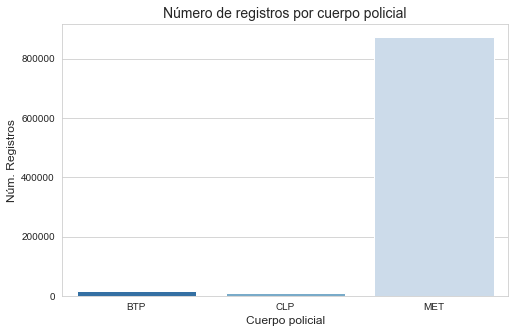

```python
# Gráfica con el número de registros seleccionados por fuerza policial
plt.figure(figsize=(8, 5))
sns.set_style('whitegrid')
sns.countplot(x='Source', data=police_data, palette='Blues_r')
plt.title('Número de registros por cuerpo policial', fontsize=14)
plt.xlabel('Cuerpo policial', fontsize=12)
plt.ylabel('Núm. Registros', fontsize=12)
plt.show()
```

Por el mismo motivo, los registros a descartar por haber sido localizados fuera de la zona de Londres son mayoritariamente de BTP. Los correspondientes a MET pueden tratarse a actuaciones en zonas limítrofes o a errores de codificación, mientras que los de CLP son con toda probabilidad errores al introducir los datos en el sistema.

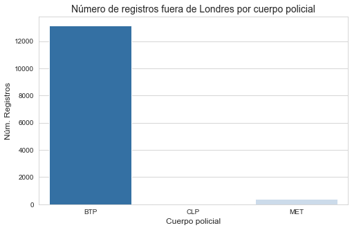

```python
# Gráfica con el número de registros fuera de Londres (descartados) por fuerza policial
fig, ax = plt.subplots(figsize=(8, 5))
sns.set_style('whitegrid')
sns.countplot(x='Source', data=discarded_data, palette='Blues_r')
plt.title('Número de registros fuera de Londres por cuerpo policial', fontsize=14)
plt.xlabel('Cuerpo policial', fontsize=12)
plt.ylabel('Núm. Registros', fontsize=12)
plt.show()
```

```python
print('Registros fuera de Londres (BTP)', (discarded_data['Source']=='BTP').sum())
print('Registros fuera de Londres (CLP)', (discarded_data['Source']=='CLP').sum())
print('Registros fuera de Londres (MET)', (discarded_data['Source']=='MET').sum())
```

```
Registros fuera de Londres (BTP) 13146
Registros fuera de Londres (CLP) 27
Registros fuera de Londres (MET) 394
```

Se muestra a continuación la evolución de registros de todo el periodo temporal considerado por cuerpo policial. Se emplean dos gráficas, una que incorpora las tres fuerzas policiales y otra que permite observar con más detalle BTP y CLP.

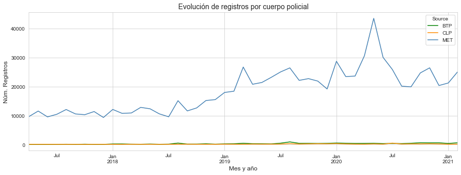

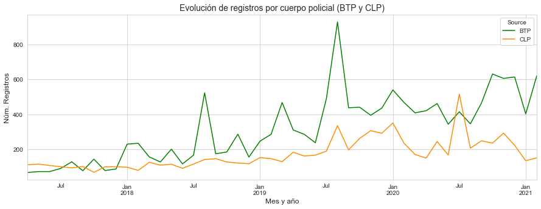

```python
# Se genera una tabla cruzada con el conteo de registros por fuerza policial
cross_data = pd.crosstab(police_data['Year-month'],
                         police_data['Source'],
                         values=police_data['Source'],
                         aggfunc='count')

# Se visualiza su evolución en una gráfica
cross_data.plot.line(figsize=(15, 5), color=['green', 'darkorange', 'steelblue'])
plt.title('Evolución de registros por cuerpo policial', fontsize=14)
plt.xlabel('Mes y año', fontsize=12)
plt.ylabel('Núm. Registros', fontsize=12)
plt.show()

# Se genera una tabla cruzada con el conteo de registros para BTP y CLP
btp_clp_data = police_data[police_data['Source'] != 'MET']
cross_data = pd.crosstab(btp_clp_data['Year-month'],
                         btp_clp_data['Source'],
                         values=btp_clp_data['Source'],
                         aggfunc='count')

# Se visualiza su evolución en una gráfica
cross_data.plot.line(figsize=(15, 5), color=['green', 'darkorange', 'steelblue'])
plt.title('Evolución de registros por cuerpo policial (BTP y CLP)', fontsize=14)
plt.xlabel('Mes y año', fontsize=12)
plt.ylabel('Núm. Registros', fontsize=12)
plt.show()
```

En los tres casos pueden apreciarse picos alrededor de los meses con mejor tiempo y un aumento ligero pero continuado para CLP y BTP, y más pronunciado para MET.  
Esta tendencia al alza llega a principios de 2020: a partir de ese momento, los tres orígenes presentan subidas y bajadas pronunciadas y un estancamiento del número de registros. La web de origen de los datos, data.police.uk, lleva un registro de posibles incidencias en la recogida de datos, pero no tiene ninguna reflejada para ese periodo. Una posible explicación podría ser el impacto en las costumbres y movimientos de personas debido a la crisis originada por la COVID-19.

### 2.1 Revisión de registros sin localización

Se realiza a continuación un breve estudio comparativo de los registros sin datos de ubicación, con el objetivo de intentar localizar algún patrón o diferencia reseñable respecto a los registros que sí cuentan con esta información.

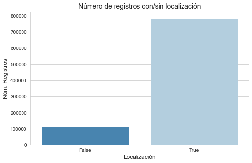

```python
# Para facilitar las comparativas relativas a registros sin y con localización, se genera una nueva
# variable en el dataset
police_data['Location'] = police_data['Borough'].notnull()

# Número de registros
plt.figure(figsize=(8, 5))
sns.set_style('whitegrid')
sns.countplot(x='Location', data=police_data, palette='Blues_r')
sns.set_style('whitegrid')
plt.title('Número de registros con/sin localización', fontsize=14)
plt.xlabel('Localización', fontsize=12)
plt.ylabel('Núm. Registros', fontsize=12)
plt.show()
```

Tanto en la gráfica superior como en la que se muestra a continuación se observa la prevalencia de registros con datos de ubicación, diferencia que va aumentando además con el paso del tiempo.  
En febrero y marzo de 2018 se produce una bajada puntual del registro de latitud y longitud en las actuaciones policiales, sin que se haya podido encontrar información que lo justifique (la web de data.police.uk no refleja ninguna incidencia en ese periodo).

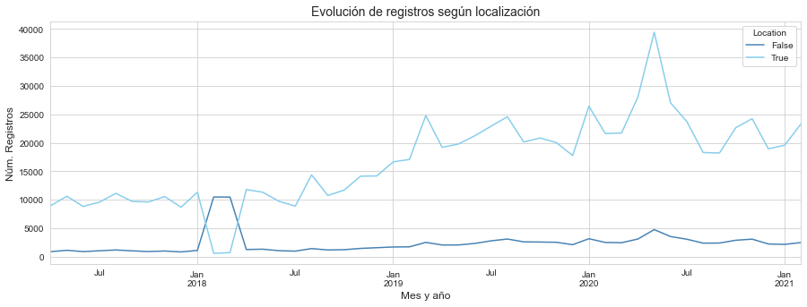

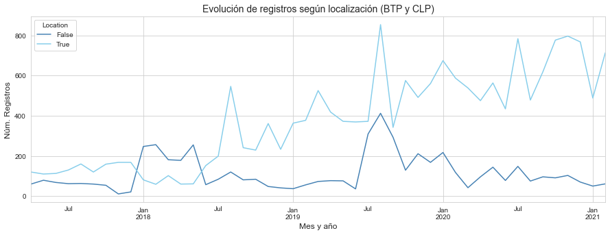

```python
# Se genera una tabla cruzada y una gráfica con el conteo de registros con y sin localización y su evolución
cross_data = pd.crosstab(police_data['Year-month'],
                         police_data['Location'],
                         values=police_data['Location'],
                         aggfunc='count')
cross_data.plot.line(figsize=(15, 5), color=['steelblue', 'skyblue'])
plt.title('Evolución de registros según localización', fontsize=14)
plt.xlabel('Mes y año', fontsize=12)
plt.ylabel('Núm. Registros', fontsize=12)
plt.show()

# Se genera una tabla cruzada y una gráfica con el conteo de registros con y sin localización para BTP y CLP
# y su evolución
btp_clp_data = police_data[police_data['Source'] != 'MET']
cross_data = pd.crosstab(btp_clp_data['Year-month'],
                         btp_clp_data['Location'],
                         values=btp_clp_data['Location'],
                         aggfunc='count')
cross_data.plot.line(figsize=(15, 5), color=['steelblue', 'skyblue'])
plt.title('Evolución de registros según localización (BTP y CLP)', fontsize=14)
plt.xlabel('Mes y año', fontsize=12)
plt.ylabel('Núm. Registros', fontsize=12)
plt.show()
```

```python
# Mostramos el detalle de registros para la franja en la que se ha observado la bajada de datos con localización
zoom = police_data[(police_data['Date']>='2018-02-01') &
                   (police_data['Date']<='2018-03-30') &
                   (police_data['Location']==False)]

pd.crosstab(zoom['Year-month'], zoom['Source'], values=zoom['Location'], aggfunc='count')
```

| Source Year-month | BTP | CLP | MET |
| --- | --- | --- | --- |
| 2018-02 | 235 | 21 | 10237 |
| 2018-03 | 144 | 23 | 9701 |

Respecto a la ubicación, la MET es el cuerpo policial con un mayor porcentaje de registros con localización, seguido de BTP. Destaca la diferencia respecto a CLP, donde más del 31% de sus registros no tienen sus coordenadas informadas.

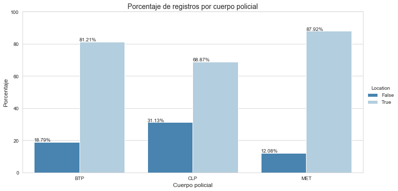

```python
# Porcentaje de registros con y sin localización por cuerpo policial
percentage_plot(police_data, 'Source', 'Location', 'Porcentaje de registros por cuerpo policial',
                'Cuerpo policial').show()
```

En cuanto a los porcentajes de registros con/sin localización por tipo de actuación o sexo, no se aprecian diferencias destacables.

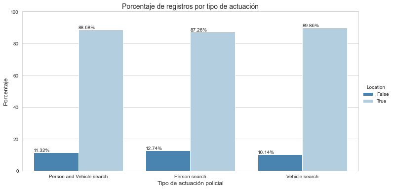

```python
# Porcentaje de registros con/sin localización por tipo de actuación policial
police_data['Type'].value_counts()
percentage_plot(police_data, 'Type', 'Location', 'Porcentaje de registros por tipo de actuación',
                'Tipo de actuación policial').show()
```

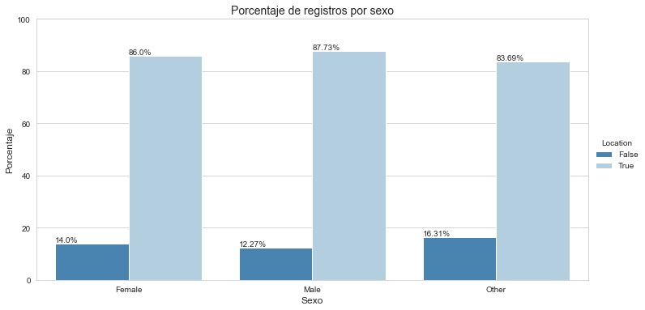

```python
# Porcentaje de registros con/sin localización por sexo
police_data['Gender'].value_counts()
percentage_plot(police_data, 'Gender', 'Location', 'Porcentaje de registros por sexo', 'Sexo').show()
```

Tampoco se aprecian diferencias reseñables respecto a la raza: en el caso del valor *Mixed*, aunque el 100% de los registros tienen la ubicación informada frente al 87-88% de las restantes etnias, esta diferencia se debe a que el dataset original tiene muy pocos registros con este valor, que no permite concluir que exista un comportamiento diferencial.

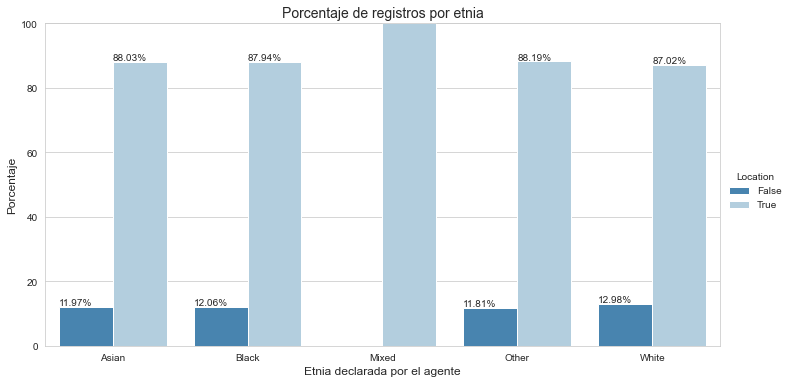

```python
# Porcentaje de registros con/sin localización por etnia
police_data['Officer-ethnicity'].value_counts()
percentage_plot(police_data, 'Officer-ethnicity', 'Location', 'Porcentaje de registros por etnia',
                'Etnia declarada por el agente').show()
```

En cuanto al tipo de resultado de la actuación policial, la mayoría de los casos suele moverse en una franja del 6-12% de registros sin localización informada. Destacan los resultados de "artículo encontrado, sin resultado disponible" y "aviso por khat o cannabis", con porcentajes muy superiores y cercanos al 50%.

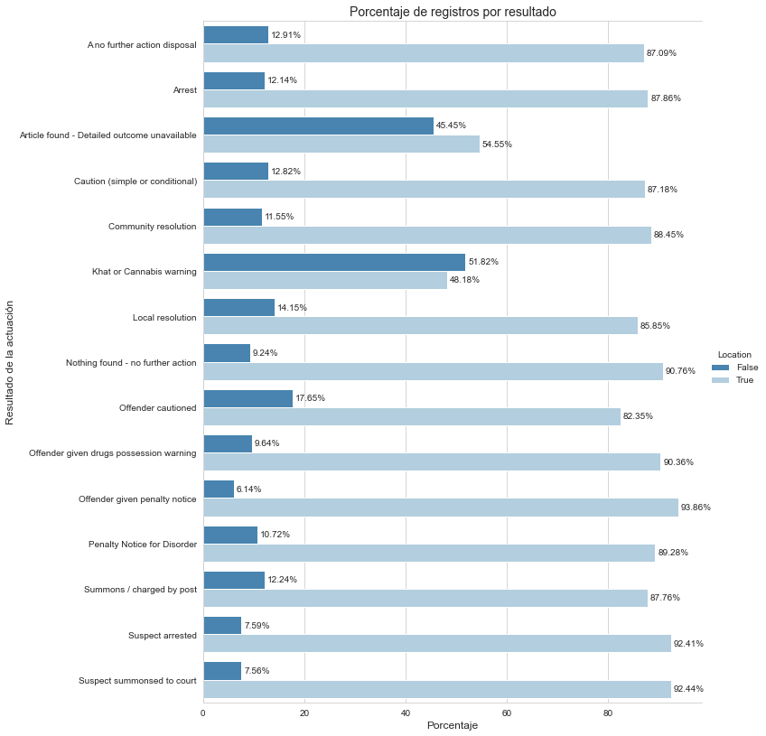

```python
# Porcentaje de registros con/sin localización por resultado
percentage_plot(police_data, 'Outcome', 'Location', 'Porcentaje de registros por resultado',
                'Porcentaje', 'Resultado de la actuación', height=11, aspect=1, orient='h').show()
```

Para el caso de las franjas de edad, los porcentajes de registros con/sin localización son homogéneos en los distintos grupos. Los porcentajes para la franja de menos de 10 años se ven afectados por el bajo número de registros en esta categoría.

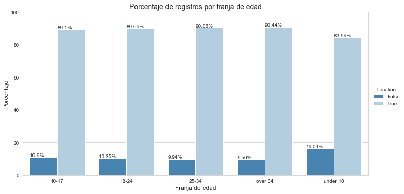

```python
# Porcentaje de registros con/sin localización por franja de edad
percentage_plot(police_data, 'Age-range', 'Location', 'Porcentaje de registros por franja de edad',
                'Franja de edad').show()
```

```python
print('Registros totales para menores de 10 años:', police_data[police_data['Age-range']=='under 10'].shape[0])
```

```
Registros totales para menores de 10 años: 212
```

### 2.2. Análisis de registros con localización en Londres

Para la elaboración de un análisis más detallado de los datos, se considerarán sólo los registros que van a utilizarse en la fase de creación del modelo, es decir, aquellos que están ubicados en Londres.

```python
# Se seleccionan los registros pertenecientes a Greater London
london_data = police_data[(police_data['Borough'].notnull())]
print('Total de registros pertenecientes a Londres:', london_data.shape[0])
```

```
Total de registros pertenecientes a Londres: 785921
```

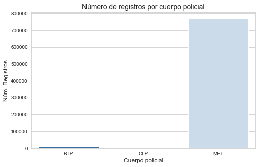

```python
# Gráfica con el número de registros seleccionados por fuerza policial
plt.figure(figsize=(8, 5))
sns.set_style('whitegrid')
sns.countplot(x='Source', data=london_data, palette='Blues_r')
plt.title('Número de registros por cuerpo policial', fontsize=14)
plt.xlabel('Cuerpo policial', fontsize=12)
plt.ylabel('Núm. Registros', fontsize=12)
plt.show()
```

```python
print('Registros totales en Londres (BTP):', london_data[london_data['Source']=='BTP'].shape[0])
print('Registros totales en Londres (CLP):', london_data[london_data['Source']=='CLP'].shape[0])
print('Registros totales en Londres (MET):', london_data[london_data['Source']=='MET'].shape[0])
```

```
Registros totales en Londres (BTP): 12261
Registros totales en Londres (CLP): 5618
Registros totales en Londres (MET): 768042
```

Se muestra a continuación un mapa coroplético de Londres con el número de actuaciones policiales por distrito y una gráfica de barras con los 15 distritos con el mayor número de *stop and search*.

```python
# Se carga el mapa de Londres
london_map = gpd.read_file('./maps/london-boroughs-map.shp')
print('Variables:', london_map.columns.values)
london_map.head()
```

```
Variables: ['NAME' 'GSS_CODE' 'HECTARES' 'NONLD_AREA' 'ONS_INNER' 'SUB_2009'
 'SUB_2006' 'geometry']
```

|  | NAME | GSS_CODE | HECTARES | NONLD_AREA | ONS_INNER | SUB_2009 | SUB_2006 | geometry |
| --- | --- | --- | --- | --- | --- | --- | --- | --- |
| 0 | Kingston upon Thames | E09000021 | 3726.117 | 0.000 | F | None | None | POLYGON ((516401.600 160201.800, 516407.300 16... |
| 1 | Croydon | E09000008 | 8649.441 | 0.000 | F | None | None | POLYGON ((535009.200 159504.700, 535005.500 15... |
| 2 | Bromley | E09000006 | 15013.487 | 0.000 | F | None | None | POLYGON ((540373.600 157530.400, 540361.200 15... |
| 3 | Hounslow | E09000018 | 5658.541 | 60.755 | F | None | None | POLYGON ((521975.800 178100.000, 521967.700 17... |
| 4 | Ealing | E09000009 | 5554.428 | 0.000 | F | None | None | POLYGON ((510253.500 182881.600, 510249.900 18... |

```python
# Se contabilizan los registros por distrito
grouped_data = london_data.groupby('Borough', as_index=False)['Location'].count()
grouped_data['Percentage'] = (grouped_data['Location'] / grouped_data['Location'].sum()) * 100

# Se hace un join por distrito con los datos necesarios para generar el mapa
map_data = london_map.set_index('NAME').join(grouped_data.set_index('Borough'))
```

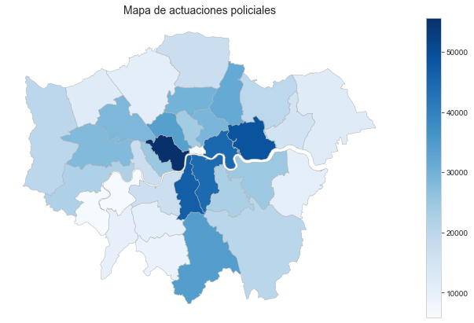

```python
# Se genera un mapa coroplético con el total de actuaciones policiales
fig, ax = plt.subplots(figsize=(15, 7))
ax.axis('off')
ax.set_title('Mapa de actuaciones policiales', fontsize='14')
map_data.plot(column='Location', cmap='Blues', ax=ax, edgecolor='0.7', linewidth=0.5, legend=True)
```

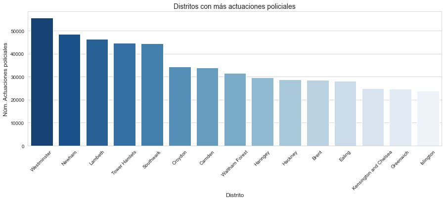

```python
# Distritos con más actuaciones policiales
top15 = grouped_data.nlargest(15, 'Location')

plt.figure(figsize=(15, 5))
sns.set_style('whitegrid')
sns.barplot(x='Borough', y='Location', data=top15,
            order=top15.sort_values('Location', ascending=False).Borough, palette='Blues_r')
plt.xlabel('Distrito', size=12)
plt.ylabel('Núm. Actuaciones policiales', size=12)
plt.title('Distritos con más actuaciones policiales', size=14)
plt.xticks(rotation=45)
plt.show()
```

Se revisan los valores perdidos del conjunto de datos tras la eliminación de aquellos registros no pertenecientes a Londres y, a continuación, se realiza una revisión detallada de las variables que constituyen el dataset.

```python
# Se revisan los valores perdidos por variable
print(london_data.isnull().sum())
```

```
Type                      0
Date                      0
Part-operation        17879
Operation            785921
Latitude                  0
Longitude                 0
Gender                11061
Age-range             80404
Self-ethnicity        10996
Officer-ethnicity     16038
Legislation              75
Object                 1958
Outcome                 200
Outcome-object       768186
More-JOG             768108
Source                    0
Address                   0
Borough                   0
Year-month                0
Location                  0
dtype: int64
```

#### 2.2.1 Variables *Operation* y *Part-operation*

Estos atributos indican si el registro efectuado por la policía está asociado a una operación policial. En cualquier caso, el alto número de valores perdidos o la poca fiabilidad de aquellos encontrados, no permite extraer información de ninguno de los dos, por lo que se procede a descartarlos.

```python
# La columna 'Operation' no está informada en ningún caso: se elimina del dataframe
london_data = london_data.drop('Operation', axis=1)
```

```python
# Se revisa la columna 'Part-operation', relacionada con la anterior

# Se comprueban los distintos valores existentes en la variable
# Información básica de la variable
print('Número de valores diferentes:', len(pd.unique(london_data['Part-operation'])))
print(london_data['Part-operation'].value_counts(dropna=False))

# Valores no nulos por fuerza policial
print('Registros informados por BTP:',
      london_data[(london_data['Part-operation'].notnull()) & (london_data['Source']=='BTP')].shape[0])
print('Registros informados por CLP:',
      london_data[(london_data['Part-operation'].notnull()) & (london_data['Source']=='CLP')].shape[0])
print('Registros informados por MET:',
      london_data[(london_data['Part-operation'].notnull()) & (london_data['Source']=='MET')].shape[0])
```

```
Número de valores diferentes: 2
False    768042
NaN       17879
Name: Part-operation, dtype: Int64
Registros informados por BTP: 0
Registros informados por CLP: 0
Registros informados por MET: 768042
```

Sólo una fuerza policial (MET) informa este campo y, además, siempre lo marca como False, por lo que se retira del dataset.

```python
# Se elimina la variable
london_data = london_data.drop('Part-operation', axis=1)
```

#### 2.2.2 Variable *Outcome*

Este atributo representa el resultado de la actuación policial llevada a cabo. Dado que se trata de la variable que se utilizará como base de las predicciones de nuestro futuro modelo, se descartarán aquellos registros que estén vacíos.

```python
# Información básica de la variable
print('Número de valores diferentes:', len(pd.unique(london_data['Outcome'])))
print(london_data['Outcome'].value_counts(dropna=False))

# Se eliminan los registros con el campo Outcome vacío
london_data = london_data.dropna(subset=['Outcome'])
```

```
Número de valores diferentes: 16
A no further action disposal                    520496
Arrest                                           86060
Nothing found - no further action                67138
Community resolution                             52243
Suspect arrested                                 18965
Penalty Notice for Disorder                      17220
Summons / charged by post                         8681
Offender given drugs possession warning           8497
Offender given penalty notice                     2126
Khat or Cannabis warning                          1677
Suspect summonsed to court                        1076
Local resolution                                   977
Caution (simple or conditional)                    483
NaN                                                200
Offender cautioned                                  70
Article found - Detailed outcome unavailable        12
Name: Outcome, dtype: int64
```

En las actuaciones policiales positivas o con éxito, es decir, aquellas que requieren de una acción policial o legal posterior por encontrarse indicios de delito, predominan los resultados correspondientes a arrestos o a resoluciones comunitarias (acuerdos alcanzados entre las partes tras la admisión de culpabilidad del sospechoso).

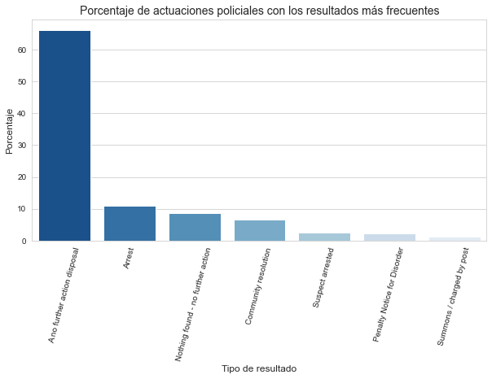

```python
# Resultados más frecuentes
top = ((london_data['Outcome']).value_counts(normalize=True, sort=True)*100).head(7)
top = top.to_frame().reset_index()
top.columns = ['Outcome', 'Percentage']

# Porcentaje de registros por resultados más frecuentes
plt.figure(figsize=(10, 5))
sns.set_style('whitegrid')
sns.barplot(x='Outcome', y='Percentage', data=top, palette='Blues_r')
plt.xlabel('Tipo de resultado', size=12)
plt.ylabel('Porcentaje', size=12)
plt.title('Porcentaje de actuaciones policiales con los resultados más frecuentes', size=14)
plt.xticks(rotation=75)
plt.show()
```

Se genera a continuación una nueva variable booleana que permite identificar los registros positivos de los negativos. Como puede observarse en el gráfico de sectores inferior, los registros considerados negativos, es decir, aquellos en los que la policía no ha encontrado indicios de delito, constituyen casi un 75% del total.

```
False    587634
True     198087
Name: Further-action, dtype: int64
```

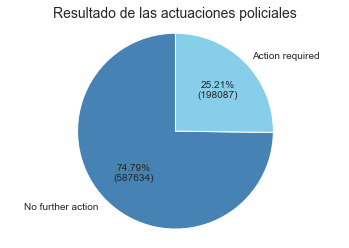

```python
# Se genera una variable a partir de los posibles valores de Outcome que diferencia entre registros policiales
# con éxito (que conllevan algún tipo de acción o sanción) y los que no (no se han encontrado motivos que requieran
# de acciones posteriores)
london_data['Further-action'] = london_data['Outcome'].apply(lambda x: False if 'no further action' in x else True)
print(london_data['Further-action'].value_counts())

# Se dibuja la gráfica
labels = ['No further action', 'Action required']
colors = ['steelblue', 'skyblue']
pie_chart(london_data, 'Further-action', 'Resultado de las actuaciones policiales', labels, colors).show()
```

A continuación se genera un mapa coroplético con el total de actuaciones policiales con resultado positivo por distrito, donde no se aprecian grandes diferencias respecto al mapa con el total de actuaciones.

```python
# Registros con resultado positivo en la actuación policial
further_action_data = london_data[london_data['Further-action']]

# Se contabilizan los registros con resultado positivo por distrito
grouped_data = further_action_data.groupby('Borough', as_index=False)['Location'].count()
grouped_data['Percentage'] = (grouped_data['Location'] / grouped_data['Location'].sum()) * 100

# Se hace un join por distrito con los datos necesarios para generar el mapa
map_data = london_map.set_index('NAME').join(grouped_data.set_index('Borough'))
```

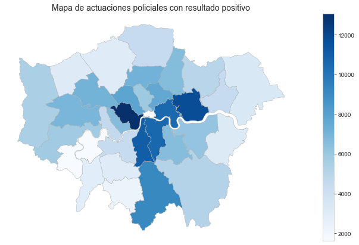

```python
# Se genera un mapa coroplético con el total de actuaciones policiales con resultado positivo
fig, ax = plt.subplots(figsize=(15, 7))
ax.axis('off')
ax.set_title('Mapa de actuaciones policiales con resultado positivo', fontsize='14')
map_data.plot(column='Location', cmap='Blues', ax=ax, edgecolor='0.7', linewidth=0.5, legend=True)
```

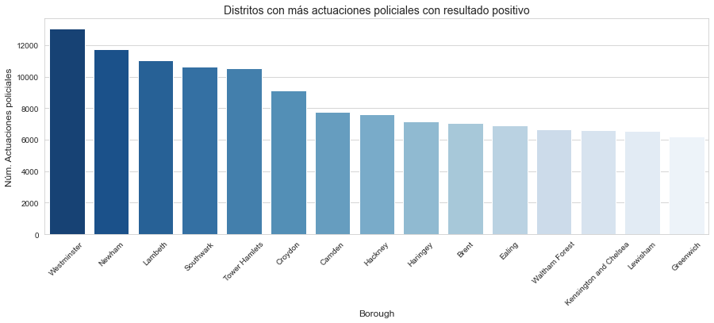

```python
# Se muestran los 15 distritos con mayor número de actuaciones con resultados positivos
top15 = grouped_data.nlargest(15, 'Location')

plt.figure(figsize=(15, 5))
sns.set_style('whitegrid')
sns.barplot(x='Borough', y='Location', data=top15,
            order=top15.sort_values('Location', ascending=False).Borough, palette='Blues_r')
plt.xlabel('Borough', size=12)
plt.ylabel('Núm. Actuaciones policiales', size=12)
plt.title('Distritos con más actuaciones policiales con resultado positivo', size=14)
plt.xticks(rotation=45)
plt.show()
```

Sin embargo, sí se pueden apreciar diferencias en la proporción de registros positivos frente a negativos de los 5 distritos con más actuaciones policiales positivas frente a los 5 con menos. Mientras que los primeros tienen un porcentaje de registros positivos entre el 23-24%, los segundos presentan una franja superior, entre el 25-29%.

```python
# Se seleccionan las filas que pertenecen a los 5 distritos con más actuaciones con resultado positivo
top5_boroughs = grouped_data.nlargest(5, 'Location')['Borough']
top5 = london_data.loc[london_data['Borough'].isin(top5_boroughs)].copy(deep=True)

# Se seleccionan las filas que pertenecen a los 5 distritos con menos actuaciones con resultado positivo
bottom5_boroughs = grouped_data.nsmallest(5, 'Location')['Borough']
bottom5 = london_data.loc[london_data['Borough'].isin(bottom5_boroughs)].copy(deep=True)
```

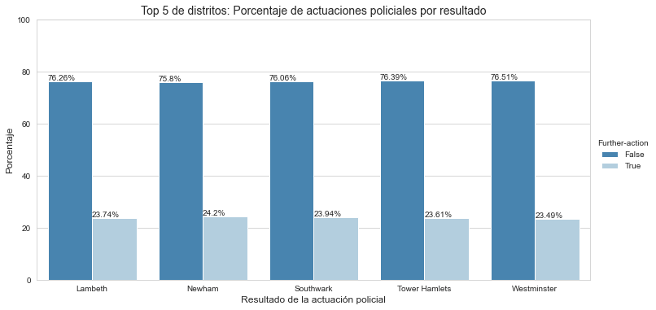

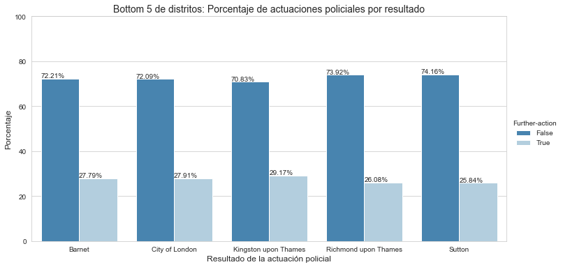

```python
# Se muestran ambas gráficas
percentage_plot(top5, 'Borough', 'Further-action',
                'Top 5 de distritos: Porcentaje de actuaciones policiales por resultado',
                'Resultado de la actuación policial').show()

percentage_plot(bottom5, 'Borough', 'Further-action',
                'Bottom 5 de distritos: Porcentaje de actuaciones policiales por resultado',
                'Resultado de la actuación policial').show()
```

Se muestra la evolución de los resultados de los registros para el top 5 y el bottom 5 a lo largo del periodo temporal considerado en el estudio.

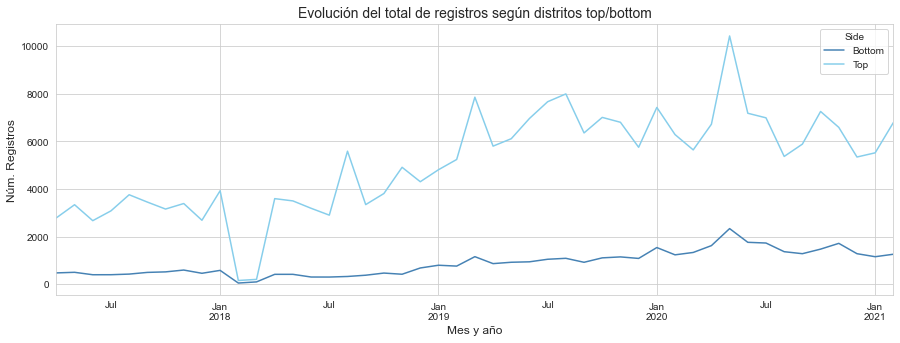

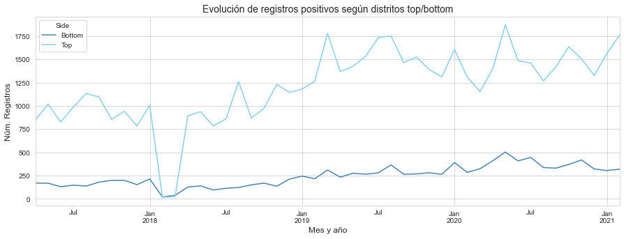

```python
# Se agrupan los registros pertenecientes a los 5 distritos con más resultados positivos y los
# 5 que menos
top5['Side'] = 'Top'
bottom5['Side'] = 'Bottom'
top_bottom_data = pd.concat([top5, bottom5])
cross_data = pd.crosstab(top_bottom_data['Year-month'],
                         top_bottom_data['Side'],
                         values=top_bottom_data['Location'],
                         aggfunc='count')

# Se visualiza su evolución en una gráfica
cross_data.plot.line(figsize=(15, 5), color=['steelblue', 'skyblue'])
plt.title('Evolución del total de registros según distritos top/bottom', fontsize=14)
plt.xlabel('Mes y año', fontsize=12)
plt.ylabel('Núm. Registros', fontsize=12)
plt.show()

# Se seleccionan sólo actuaciones con resultado positivo en los distritos con más positivos
further_action_top5 = further_action_data.loc[further_action_data['Borough'].isin(top5_boroughs)].copy(deep=True)

# Se seleccionan sólo actuaciones con resultado positivo en los distritos con menos positivos
further_action_bottom5 = further_action_data.loc[further_action_data['Borough'].isin(bottom5_boroughs)].copy(deep=True)

further_action_top5['Side'] = 'Top'
further_action_bottom5['Side'] = 'Bottom'

# Se genera un nuevo dataframe con ambos conjuntos de datos
fa_top_bottom_data = pd.concat([further_action_top5, further_action_bottom5])
cross_data = pd.crosstab(fa_top_bottom_data['Year-month'],
                         fa_top_bottom_data['Side'],
                         values=fa_top_bottom_data['Location'],
                         aggfunc='count')

# Se visualiza su evolución en una gráfica
cross_data.plot.line(figsize=(15, 5), color=['steelblue', 'skyblue'])
plt.title('Evolución de registros positivos según distritos top/bottom', fontsize=14)
plt.xlabel('Mes y año', fontsize=12)
plt.ylabel('Núm. Registros', fontsize=12)
plt.show()
```

#### 2.2.3 Variable *Type*

Indica el tipo de detención realizada: registro de personas, de vehículos o ambos. Predomina con más del 75% de los casos el registro de personas.

```
Número de valores diferentes: 3
Person search                589746
Person and Vehicle search    183556
Vehicle search                12419
Name: Type, dtype: int64
```

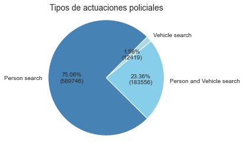

```python
# Información básica de la variable
print('Número de valores diferentes:', len(pd.unique(london_data['Type'])))
print(london_data['Type'].value_counts(dropna=False))

# Se muestra la proporción de valores en un gráfico de sectores
labels = ['Person search', 'Person and Vehicle search', 'Vehicle search']
colors = ['steelblue', 'skyblue', 'lightblue']
pie_chart(london_data, 'Type', 'Tipos de actuaciones policiales', labels, colors, 45).show()
```

La búsqueda que menos resultados positivos arroja es la relativa a personas. Las intervenciones con mayores probabilidades de éxito son las que se realizan tanto sobre la persona como sobre el vehículo.

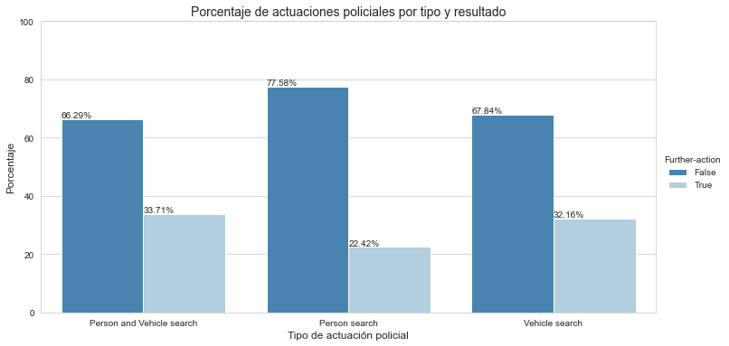

```python
# Porcentaje de registros por tipo y resultado
percentage_plot(london_data, 'Type', 'Further-action',
                'Porcentaje de actuaciones policiales por tipo y resultado',
                'Tipo de actuación policial').show()
```

En cuanto al tipo de registro que realizan los diferentes cuerpos de policia, no sorprende encontrar que la BTP se centra sobre todo en registros de personas, dado que actúa en los medios de transporte públicos.

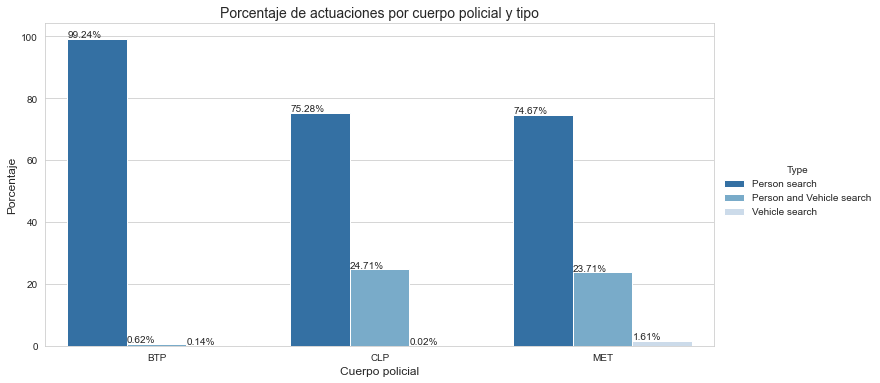

```python
# Porcentaje de registros por tipo y fuerza policial
percentage_plot(london_data, 'Source', 'Type',
                'Porcentaje de actuaciones por cuerpo policial y tipo',
                'Cuerpo policial', limit_y=False).show()
```

#### 2.2.4 Variable *Gender*

Indica el sexo de la persona involucrada en la intervención policial. Además de las categorías de hombre, mujer y otros, se asigna un valor por defecto a los registros con valor perdido.

El número de este tipo de actuaciones en hombres es muy superior al del resto de categorías, llegando a superar el 90% del total.

```
Número de valores diferentes: 4
Male      722070
Female     52200
NaN        11015
Other        436
Name: Gender, dtype: int64
```

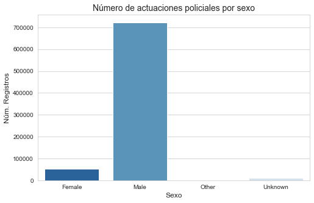

```python
# Información básica de la variable
print('Número de valores diferentes:', len(pd.unique(london_data['Gender'])))
print(london_data['Gender'].value_counts(dropna=False))

# Se asigna un valor por defecto a los registros con valor desconocido
london_data['Gender'] = london_data['Gender'].fillna('Unknown')

# Gráfica con el número de actuaciones policiales por sexo
plt.figure(figsize=(8, 5))
sns.set_style('whitegrid')
sns.countplot(x='Gender', data=london_data, palette='Blues_r', order=sorted(london_data['Gender'].unique()))
plt.title('Número de actuaciones policiales por sexo', fontsize=14)
plt.xlabel('Sexo', fontsize=12)
plt.ylabel('Núm. Registros', fontsize=12)
plt.show()
```

A excepción de los registros correspondientes a los valores perdidos, el resto de categorías presentan porcentajes muy parecidos de actuaciones positivas y negativas.

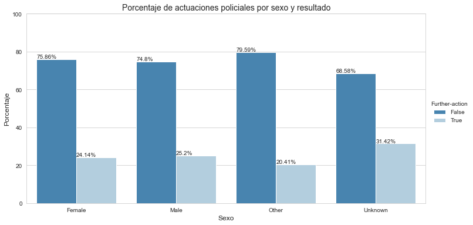

```python
# Porcentaje de registros por sexo y resultado
percentage_plot(london_data, 'Gender', 'Further-action',
                'Porcentaje de actuaciones policiales por sexo y resultado',
                'Sexo').show()
```

Se realiza una comparativa de los tipos de resultados más habituales en aquellos casos en los que la policía detecta actividad sospechosa para hombres y mujeres.

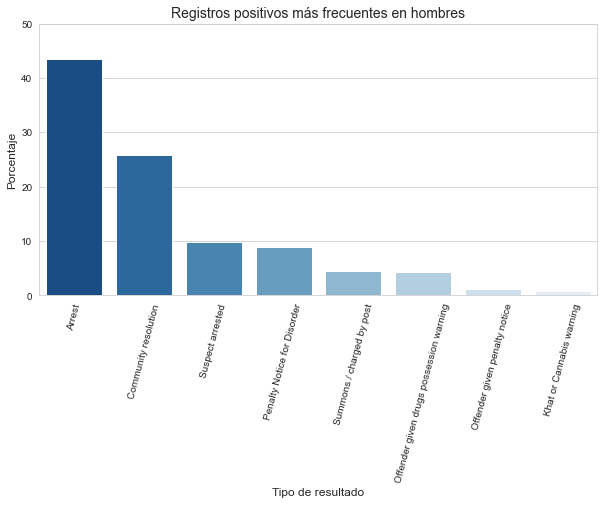

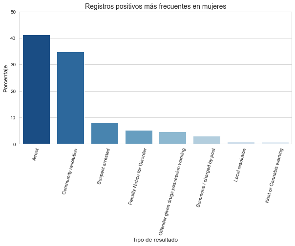

```python
# Comparativa de tipos de resultados por sexo

# Seleccion de registros con los resultados positivos más frecuentes en hombres
fa_male_data = london_data[(london_data['Further-action']) & (london_data['Gender']=='Male')]
top_fa_male = ((fa_male_data['Outcome']).value_counts(normalize=True, sort=True)*100).head(8)
top_fa_male = top_fa_male.to_frame().reset_index()
top_fa_male.columns = ['Outcome', 'Percentage']

# Seleccion de registros con los resultados positivos más frecuentes en mujeres
fa_female_data = london_data[(london_data['Further-action']) & (london_data['Gender']=='Female')]
top_fa_female = ((fa_female_data['Outcome']).value_counts(normalize=True, sort=True)*100).head(8)
top_fa_female = top_fa_female.to_frame().reset_index()
top_fa_female.columns = ['Outcome', 'Percentage']

# Gráfica de resultados más frecuentes para hombres
plt.figure(figsize=(10, 5))
sns.set_style('whitegrid')
sns.barplot(x='Outcome', y='Percentage', data=top_fa_male, palette='Blues_r')
plt.xlabel('Tipo de resultado', size=12)
plt.ylabel('Porcentaje', size=12)
plt.title('Registros positivos más frecuentes en hombres', size=14)
plt.ylim(0, 50)
plt.xticks(rotation=75)
plt.show()

# Gráfica de resultados más frecuentes para mujeres
plt.figure(figsize=(10, 5))
sns.set_style('whitegrid')
sns.barplot(x='Outcome', y='Percentage', data=top_fa_female, palette='Blues_r')
plt.xlabel('Tipo de resultado', size=12)
plt.ylabel('Porcentaje', size=12)
plt.title('Registros positivos más frecuentes en mujeres', size=14)
plt.ylim(0, 50)
plt.xticks(rotation=75)
plt.show()
```

Los resultados son muy parecidos, aunque en el caso de las mujeres los cargos por posesión de drogas ocupan la 5ª posición de la lista, mientras que en los hombres están en la 6ª. Las resoluciones locales no aparecen en el ranquin de hombres aunque sí en el de mujeres y, en su lugar, aparecen infracciones sancionadas con multas.